# Regression & Hypothesis Testing: Continous Y, Categorical X

2021-08-27

## Palmer penguins dataset

I’ve been watching a lot of Atypical recently and also found out there’s a dataset with some of the penguins Sam talks about.

This will show how to do regression with categorical variables, and look at similarities with hypothesis testing using t-tests. I’ll go into what’s happening in the background and why we can get the same result from a t-test and regression.

```r
library(palmerpenguins)
library(ggplot2)
library(scatterplot3d)

penguins
```

```
## # A tibble: 344 x 8
##    species island bill_length_mm bill_depth_mm flipper_length_~ body_mass_g
##    <fct>   <fct>           <dbl>         <dbl>            <int>       <int>
##  1 Adelie  Torge~           39.1          18.7              181        3750
##  2 Adelie  Torge~           39.5          17.4              186        3800
##  3 Adelie  Torge~           40.3          18                195        3250
##  4 Adelie  Torge~           NA            NA                 NA          NA
##  5 Adelie  Torge~           36.7          19.3              193        3450
##  6 Adelie  Torge~           39.3          20.6              190        3650
##  7 Adelie  Torge~           38.9          17.8              181        3625
##  8 Adelie  Torge~           39.2          19.6              195        4675
##  9 Adelie  Torge~           34.1          18.1              193        3475
## 10 Adelie  Torge~           42            20.2              190        4250
## # ... with 334 more rows, and 2 more variables: sex <fct>, year <int>
```

```r
# Remove NAs
penguins_df = na.omit(penguins)
```

Histogram / Density plot:

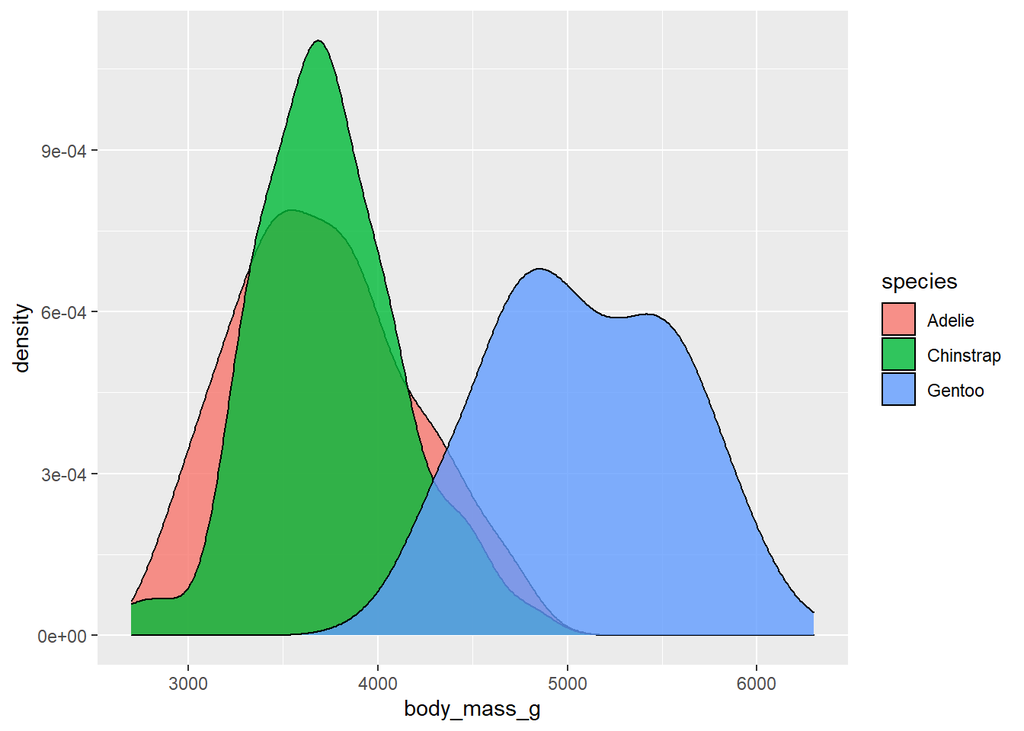

```r
#position='identity' makes sure its not stacked
#ggplot(penguins_df, aes(x=body_mass_g, fill=species, color=species)) + geom_histogram(alpha=0.4, position='identity')

ggplot(penguins_df, aes(x=body_mass_g, fill=species)) + geom_density(alpha=0.8)
```

```r
# Mean body mass for each species
aggregate(body_mass_g ~ species, penguins_df, mean)
```

```
##     species body_mass_g
## 1    Adelie    3706.164
## 2 Chinstrap    3733.088
## 3    Gentoo    5092.437
```

```r
# Number of data points for each species
aggregate(body_mass_g ~ species, penguins_df, length)
```

```
##     species body_mass_g
## 1    Adelie         146
## 2 Chinstrap          68
## 3    Gentoo         119
```

Let’s test the difference between body mass of Adelie and Chinstrap using regression and compare the result to a t-test.

```r
# Here we keep rows that contain Adelie or Chinstrap and only keep species and body_mass_g column
test_df = penguins_df[penguins_df$species %in% c('Adelie','Chinstrap'), c("species","body_mass_g")]

# Create factors again to remove unused factor level:
test_df$species = factor(test_df$species)

# Difference between means:
diff(by(test_df$body_mass_g, test_df$species, mean))
```

```
## [1] 26.92385
```

## Regression with categorical variables

Our x variable (species) is a category/factor. In python, you might have to use one hot encoding on your categorical variables before you pass your data into a linear model. The nice thing about R is that it does the one hot encoding/dummy coding on factors automagically for us.

```r
two_lvl_model = lm(body_mass_g ~ species, data = test_df)
summary(two_lvl_model)
```

```
##
## Call:
## lm(formula = body_mass_g ~ species, data = test_df)
##
## Residuals:
##      Min       1Q   Median       3Q      Max
## -1033.09  -306.16   -20.59   268.35  1068.84
##
## Coefficients:
##                  Estimate Std. Error t value Pr(>|t|)
## (Intercept)       3706.16      36.13  102.59   <2e-16 ***
## speciesChinstrap    26.92      64.09    0.42    0.675
## ---
## Signif. codes:  0 '***' 0.001 '**' 0.01 '*' 0.05 '.' 0.1 ' ' 1
##
## Residual standard error: 436.5 on 212 degrees of freedom
## Multiple R-squared:  0.0008318,  Adjusted R-squared:  -0.003881
## F-statistic: 0.1765 on 1 and 212 DF,  p-value: 0.6748
```

### Dummy Coding / One-Hot Encoding

Let’s manually do the dummy coding and compare results. If you think about a linear model $y=mx+b$ where $x$ is species and $y$ is body mass, we need $x$ to be 0 for one category and 1 for the other. In this case let’s make Chinstrap 1 and Adelie 0.

```r
# Manually create dummy variables:
test_df$x = ifelse(test_df$species == 'Chinstrap',1,0)
```

Now we do regression with our new variable $x$.

```r
two_lvl_dummy = lm(body_mass_g ~ x, data = test_df)
summary(two_lvl_dummy)
```

```
##
## Call:
## lm(formula = body_mass_g ~ x, data = test_df)
##
## Residuals:
##      Min       1Q   Median       3Q      Max
## -1033.09  -306.16   -20.59   268.35  1068.84
##
## Coefficients:
##             Estimate Std. Error t value Pr(>|t|)
## (Intercept)  3706.16      36.13  102.59   <2e-16 ***
## x              26.92      64.09    0.42    0.675
## ---
## Signif. codes:  0 '***' 0.001 '**' 0.01 '*' 0.05 '.' 0.1 ' ' 1
##
## Residual standard error: 436.5 on 212 degrees of freedom
## Multiple R-squared:  0.0008318,  Adjusted R-squared:  -0.003881
## F-statistic: 0.1765 on 1 and 212 DF,  p-value: 0.6748
```

We see that we got the exact same result as before.

### Intrepreting Regression Coefficients

```r
# Intercept:
two_lvl_model$coefficients[1]
```

```
## (Intercept)
##    3706.164
```

```r
# Slope
two_lvl_model$coefficients[2]
```

```
## speciesChinstrap
##         26.92385
```

Let’s go back to the equation for this linear model, keeping in mind the dummy coding of our categorical variable. Adelie is represented by $x = 0$ and Chinstrap is $x = 1$.

I guess I didn’t answer the real questions: Why is the slope the mean difference? Why is it that the line passes through the mean of both groups?

Let’s plot the situation:

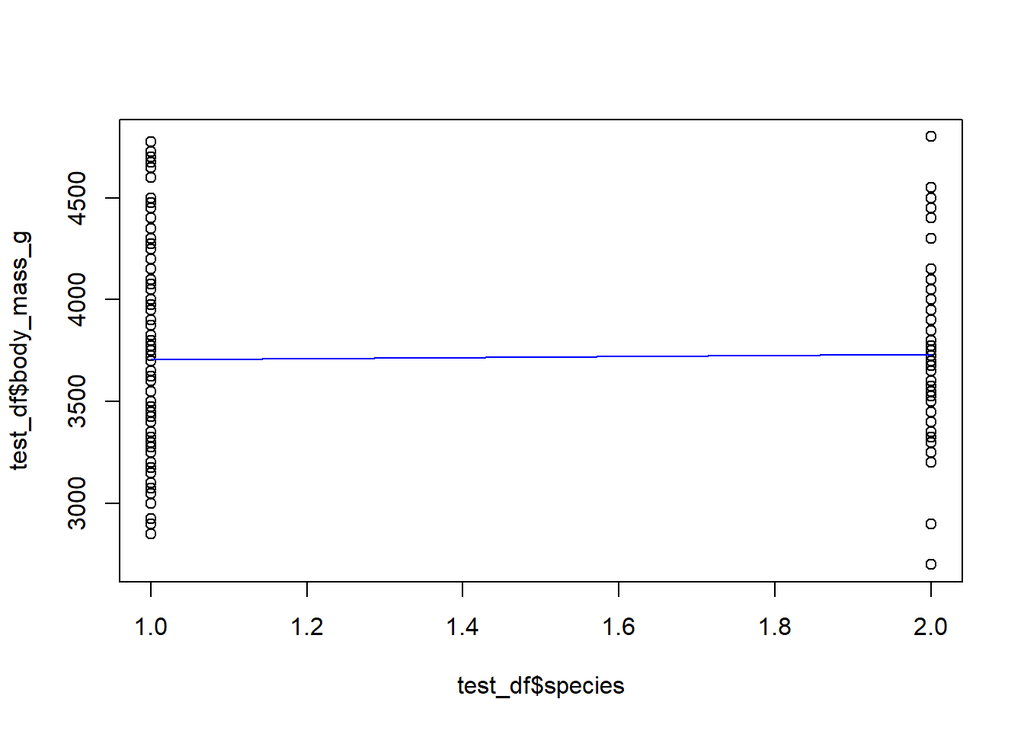

```r
plot.default(x=test_df$species, y=test_df$body_mass_g)
lines(test_df$species, predict(two_lvl_model),col='blue')
```

The way the slope and intercept are calculated is called Oridnary Least Squares. It minimizes the sum of squared deviations. For every x variable our model predicts a value $\hat{y_i}$. Our x variable is categorical with 2 levels: Adelie(0) or Chinstrap(1).

$\sum_{i=1}^{n} (y_i - \hat{y_i})^{2}$

The least squares formula works by minimizing the sum of squared deviations. In this case the mean of both groups is what minimizes the sum of squared errors.

The line of best fit passes through both group means. The group means minimize the squared errors.

### Interpreting t-value & p-value of the slope:

What does the t-value represent here? Why does regression have a t-value at all? Where is null t distribution and the area under the curve?

It is essentially a one sample t-test. The t-value and p-value are from a one sample t-test on the regression coefficient. And as we saw above, in this case the slope *is* the mean difference. So we are in a sense testing if the difference in means is different from 0. If we compare the p-value of the slope here to a t-test or permutation test, we should see similar results. In fact, it should be identical to the t-test that uses pooled variance.

The statistical test which is conducted for the statistical significance of the coefficient is a one sample t-test. This is confusing since we do not have a “sample” of multiple coefficients for X4, but we have an estimate of the distributional properties of such a sample using the central limit theorem. The mean and standard error describe the location and shape of such a limiting distribution. If you take the column “Est” and divide by “SE” that gives you the t-value. If you use the t-value and look it up on a t-distribution with the given degrees of freedom, this gives you the p-values.

We can also compare this result to what we would get from a t-test:

## Regression vs t-test:

```r
# If you set var.equal = T it will give the same t-value & p-value as the regression
t.test(test_df$body_mass_g ~ test_df$species, var.equal = T)
```

```
##
##  Two Sample t-test
##
## data:  test_df$body_mass_g by test_df$species
## t = -0.42011, df = 212, p-value = 0.6748
## alternative hypothesis: true difference in means is not equal to 0
## 95 percent confidence interval:
##  -153.2538   99.4061
## sample estimates:
##    mean in group Adelie mean in group Chinstrap
##                3706.164                3733.088
```

### Why is the p-value for t-test and regression exactly the same?

T-test forumla:

$$t = \frac{\bar{x_1} - \bar{x_2}}{ \sqrt{s_p^2 (\frac{1}{n_1} + \frac{1}{n_2}) }}$$

The denominator is the pooled standard error and $s_p^2$ is the pooled variance which is:

$$s_p^2 = \frac{\sum_{i=1}^{n_1}(x_i - \bar{x_1}) + \sum_{j=1}^{n_2}(x_j - \bar{x_2})}{n_1 + n_2 - 2}$$

Which can also be written as (see [here](https://stackoverflow.com/a/21385702)):

$$s_p^2 = \frac{(n_1 - 1)s_1^2 + n_2 - 1 (s_2^2)}{n_1 + n_2 - 2}$$

```r
# Variacne estimator of coefficients from linear model that meets assumptions:
# In this case Xs are just 0 or 1, Y is the body mass for respective species

var1 = var(test_df$body_mass_g[test_df$species == "Chinstrap"])
var2 = var(test_df$body_mass_g[test_df$species == "Adelie"])

n1 = length(test_df$body_mass_g[test_df$species == "Chinstrap"])
n2 = length(test_df$body_mass_g[test_df$species == "Adelie"])

# Pooled variance:
var_pool = ( (n1-1)*var1 + (n2-1) * var2) / (n1+n2-2)

# Pooled standard error:
se_pool = sqrt( var_pool * (1/n1 + 1/n2) )
```

### Regression t-value:

Variance of the slope (sigma is variance of the error term):
$$\frac{\sigma^{2}}{\sum(X_i - \bar{X})^{2}}$$

Here is a video showing the derivation for variance: https://www.youtube.com/watch?v=rODUBTRUV0U&ab_channel=jbstatistics

And a stack post explaining standard error: https://stats.stackexchange.com/questions/85943/how-to-derive-the-standard-error-of-linear-regression-coefficient

You can kind of think of SE of slope in a similar manner to to SE of any data. The SE of data is when you repeatedly sample the data and get the mean. This distribution is called the sampling distribution of the mean and the SD of this distribution is the SE. Central limit theorm tells us the SE is $\frac{\sigma}{\sqrt{n}}$.

Similarly for slope, imagine if you repeatedly sampled your data and calculated the slope of the best fit line. If the residuals are small, we might except slope to have a narrower range of values. If the residuals are large we are less sure of the true value of the slope, and thus might have a larger range of values.

```r
# SE of the slope is the same as SE pooled
sqrt(sum((two_lvl_model$residuals - mean(two_lvl_model$residuals))^2) / (length( two_lvl_model$residuals) - 2)) / sqrt(sum( (test_df$x - mean(test_df$x) )^2 ))
```

```
## [1] 64.08729
```

The regression t-value is calculated using estimates of the mean difference and standard error obtained mathematically.

## Regression with a factor with 3 levels:

```r
three_lvl_model = lm(body_mass_g ~ species, data = penguins_df)
summary(three_lvl_model)
```

```
##
## Call:
## lm(formula = body_mass_g ~ species, data = penguins_df)
##
## Residuals:
##      Min       1Q   Median       3Q      Max
## -1142.44  -342.44   -33.09   307.56  1207.56
##
## Coefficients:
##                  Estimate Std. Error t value Pr(>|t|)
## (Intercept)       3706.16      38.14  97.184   <2e-16 ***
## speciesChinstrap    26.92      67.65   0.398    0.691
## speciesGentoo     1386.27      56.91  24.359   <2e-16 ***
## ---
## Signif. codes:  0 '***' 0.001 '**' 0.01 '*' 0.05 '.' 0.1 ' ' 1
##
## Residual standard error: 460.8 on 330 degrees of freedom
## Multiple R-squared:  0.6745, Adjusted R-squared:  0.6725
## F-statistic: 341.9 on 2 and 330 DF,  p-value: < 2.2e-16
```